# Risk Factor Analysis

## Outcome Variable

**Outcome Variable:** y_rate_len

## Predictor Variables

**Intervention Variable:** exclfeed36

**Adjustment Set:**

- arm
- sex
- brthmon
- W_mage
- meducyrs
- feducyrs
- hhwealth_quart
- hfoodsec
- W_mhtcm
- W_mwtkg
- W_mbmi
- vagbrth
- W_birthwt
- W_birthlen
- W_nrooms
- month
- W_parity
- impfloor
- impsan
- safeh20
- delta_W_mage
- delta_meducyrs
- delta_feducyrs
- delta_hhwealth_quart
- delta_hfoodsec
- delta_W_mhtcm
- delta_W_mwtkg
- delta_W_mbmi
- delta_vagbrth
- delta_W_birthwt
- delta_W_birthlen
- delta_W_nrooms
- delta_month
- delta_W_parity
- delta_impfloor
- delta_impsan
- delta_safeh20

## Stratifying Variables

The analysis was stratified on these variable(s):

- agecat
- studyid
- country

## Data Summary

| agecat | studyid | country | exclfeed36 | n_cell | n | outcome_variable |
| --- | --- | --- | --- | --- | --- | --- |
| 0-3 months | ki0047075b-MAL-ED | BANGLADESH | 1 | 32 | 242 | y_rate_len |
| 0-3 months | ki0047075b-MAL-ED | BANGLADESH | 0 | 210 | 242 | y_rate_len |
| 0-3 months | ki0047075b-MAL-ED | BRAZIL | 1 | 8 | 167 | y_rate_len |
| 0-3 months | ki0047075b-MAL-ED | BRAZIL | 0 | 159 | 167 | y_rate_len |
| 0-3 months | ki0047075b-MAL-ED | INDIA | 1 | 4 | 181 | y_rate_len |
| 0-3 months | ki0047075b-MAL-ED | INDIA | 0 | 177 | 181 | y_rate_len |
| 0-3 months | ki0047075b-MAL-ED | NEPAL | 1 | 4 | 154 | y_rate_len |
| 0-3 months | ki0047075b-MAL-ED | NEPAL | 0 | 150 | 154 | y_rate_len |
| 0-3 months | ki0047075b-MAL-ED | PERU | 1 | 5 | 263 | y_rate_len |
| 0-3 months | ki0047075b-MAL-ED | PERU | 0 | 258 | 263 | y_rate_len |
| 0-3 months | ki0047075b-MAL-ED | SOUTH AFRICA | 1 | 0 | 209 | y_rate_len |
| 0-3 months | ki0047075b-MAL-ED | SOUTH AFRICA | 0 | 209 | 209 | y_rate_len |
| 0-3 months | ki0047075b-MAL-ED | TANZANIA, UNITED REPUBLIC OF | 1 | 3 | 223 | y_rate_len |
| 0-3 months | ki0047075b-MAL-ED | TANZANIA, UNITED REPUBLIC OF | 0 | 220 | 223 | y_rate_len |
| 0-3 months | ki1000108-CMC-V-BCS-2002 | INDIA | 1 | 2 | 2 | y_rate_len |
| 0-3 months | ki1000108-CMC-V-BCS-2002 | INDIA | 0 | 0 | 2 | y_rate_len |
| 0-3 months | ki1000108-IRC | INDIA | 1 | 0 | 4 | y_rate_len |
| 0-3 months | ki1000108-IRC | INDIA | 0 | 4 | 4 | y_rate_len |
| 0-3 months | ki1000109-EE | PAKISTAN | 1 | 2 | 6 | y_rate_len |
| 0-3 months | ki1000109-EE | PAKISTAN | 0 | 4 | 6 | y_rate_len |
| 0-3 months | ki1017093b-PROVIDE | BANGLADESH | 1 | 161 | 634 | y_rate_len |
| 0-3 months | ki1017093b-PROVIDE | BANGLADESH | 0 | 473 | 634 | y_rate_len |
| 0-3 months | ki1101329-Keneba | GAMBIA | 1 | 326 | 1116 | y_rate_len |
| 0-3 months | ki1101329-Keneba | GAMBIA | 0 | 790 | 1116 | y_rate_len |
| 0-3 months | ki1113344-GMS-Nepal | NEPAL | 1 | 372 | 465 | y_rate_len |
| 0-3 months | ki1113344-GMS-Nepal | NEPAL | 0 | 93 | 465 | y_rate_len |
| 0-3 months | kiGH5241-JiVitA-3 | BANGLADESH | 1 | 7572 | 9726 | y_rate_len |
| 0-3 months | kiGH5241-JiVitA-3 | BANGLADESH | 0 | 2154 | 9726 | y_rate_len |
| 0-3 months | kiGH5241-JiVitA-4 | BANGLADESH | 1 | 1916 | 2307 | y_rate_len |
| 0-3 months | kiGH5241-JiVitA-4 | BANGLADESH | 0 | 391 | 2307 | y_rate_len |

[output cut: 214 more lines]

The following strata were considered:

- agecat: 0-3 months, studyid: ki0047075b-MAL-ED, country: BANGLADESH
- agecat: 0-3 months, studyid: ki0047075b-MAL-ED, country: BRAZIL
- agecat: 0-3 months, studyid: ki0047075b-MAL-ED, country: INDIA
- agecat: 0-3 months, studyid: ki0047075b-MAL-ED, country: NEPAL
- agecat: 0-3 months, studyid: ki0047075b-MAL-ED, country: PERU
- agecat: 0-3 months, studyid: ki0047075b-MAL-ED, country: SOUTH AFRICA
- agecat: 0-3 months, studyid: ki0047075b-MAL-ED, country: TANZANIA, UNITED REPUBLIC OF
- agecat: 0-3 months, studyid: ki1000108-CMC-V-BCS-2002, country: INDIA
- agecat: 0-3 months, studyid: ki1000108-IRC, country: INDIA
- agecat: 0-3 months, studyid: ki1000109-EE, country: PAKISTAN
- agecat: 0-3 months, studyid: ki1017093b-PROVIDE, country: BANGLADESH
- agecat: 0-3 months, studyid: ki1101329-Keneba, country: GAMBIA
- agecat: 0-3 months, studyid: ki1113344-GMS-Nepal, country: NEPAL
- agecat: 0-3 months, studyid: kiGH5241-JiVitA-3, country: BANGLADESH
- agecat: 0-3 months, studyid: kiGH5241-JiVitA-4, country: BANGLADESH
- agecat: 12-15 months, studyid: ki0047075b-MAL-ED, country: BANGLADESH
- agecat: 12-15 months, studyid: ki0047075b-MAL-ED, country: BRAZIL
- agecat: 12-15 months, studyid: ki0047075b-MAL-ED, country: INDIA
- agecat: 12-15 months, studyid: ki0047075b-MAL-ED, country: NEPAL
- agecat: 12-15 months, studyid: ki0047075b-MAL-ED, country: PERU
- agecat: 12-15 months, studyid: ki0047075b-MAL-ED, country: SOUTH AFRICA
- agecat: 12-15 months, studyid: ki0047075b-MAL-ED, country: TANZANIA, UNITED REPUBLIC OF
- agecat: 12-15 months, studyid: ki1000108-CMC-V-BCS-2002, country: INDIA
- agecat: 12-15 months, studyid: ki1000108-IRC, country: INDIA
- agecat: 12-15 months, studyid: ki1000109-EE, country: PAKISTAN
- agecat: 12-15 months, studyid: ki1000304b-SAS-FoodSuppl, country: INDIA
- agecat: 12-15 months, studyid: ki1017093b-PROVIDE, country: BANGLADESH
- agecat: 12-15 months, studyid: ki1101329-Keneba, country: GAMBIA
- agecat: 12-15 months, studyid: ki1113344-GMS-Nepal, country: NEPAL
- agecat: 12-15 months, studyid: ki1148112-LCNI-5, country: MALAWI
- agecat: 12-15 months, studyid: kiGH5241-JiVitA-4, country: BANGLADESH
- agecat: 15-18 months, studyid: ki0047075b-MAL-ED, country: BANGLADESH
- agecat: 15-18 months, studyid: ki0047075b-MAL-ED, country: BRAZIL
- agecat: 15-18 months, studyid: ki0047075b-MAL-ED, country: INDIA
- agecat: 15-18 months, studyid: ki0047075b-MAL-ED, country: NEPAL
- agecat: 15-18 months, studyid: ki0047075b-MAL-ED, country: PERU
- agecat: 15-18 months, studyid: ki0047075b-MAL-ED, country: SOUTH AFRICA
- agecat: 15-18 months, studyid: ki0047075b-MAL-ED, country: TANZANIA, UNITED REPUBLIC OF
- agecat: 15-18 months, studyid: ki1000108-CMC-V-BCS-2002, country: INDIA
- agecat: 15-18 months, studyid: ki1000108-IRC, country: INDIA
- agecat: 15-18 months, studyid: ki1000109-EE, country: PAKISTAN
- agecat: 15-18 months, studyid: ki1000304b-SAS-FoodSuppl, country: INDIA
- agecat: 15-18 months, studyid: ki1017093b-PROVIDE, country: BANGLADESH
- agecat: 15-18 months, studyid: ki1101329-Keneba, country: GAMBIA
- agecat: 15-18 months, studyid: ki1113344-GMS-Nepal, country: NEPAL
- agecat: 15-18 months, studyid: ki1148112-LCNI-5, country: MALAWI
- agecat: 15-18 months, studyid: kiGH5241-JiVitA-4, country: BANGLADESH
- agecat: 18-21 months, studyid: ki0047075b-MAL-ED, country: BANGLADESH
- agecat: 18-21 months, studyid: ki0047075b-MAL-ED, country: BRAZIL
- agecat: 18-21 months, studyid: ki0047075b-MAL-ED, country: INDIA
- agecat: 18-21 months, studyid: ki0047075b-MAL-ED, country: NEPAL
- agecat: 18-21 months, studyid: ki0047075b-MAL-ED, country: PERU
- agecat: 18-21 months, studyid: ki0047075b-MAL-ED, country: SOUTH AFRICA
- agecat: 18-21 months, studyid: ki0047075b-MAL-ED, country: TANZANIA, UNITED REPUBLIC OF
- agecat: 18-21 months, studyid: ki1000108-CMC-V-BCS-2002, country: INDIA
- agecat: 18-21 months, studyid: ki1000108-IRC, country: INDIA
- agecat: 18-21 months, studyid: ki1000109-EE, country: PAKISTAN
- agecat: 18-21 months, studyid: ki1017093b-PROVIDE, country: BANGLADESH
- agecat: 18-21 months, studyid: ki1101329-Keneba, country: GAMBIA
- agecat: 18-21 months, studyid: ki1113344-GMS-Nepal, country: NEPAL
- agecat: 18-21 months, studyid: ki1148112-LCNI-5, country: MALAWI
- agecat: 21-24 months, studyid: ki0047075b-MAL-ED, country: BANGLADESH
- agecat: 21-24 months, studyid: ki0047075b-MAL-ED, country: BRAZIL
- agecat: 21-24 months, studyid: ki0047075b-MAL-ED, country: INDIA
- agecat: 21-24 months, studyid: ki0047075b-MAL-ED, country: NEPAL
- agecat: 21-24 months, studyid: ki0047075b-MAL-ED, country: PERU
- agecat: 21-24 months, studyid: ki0047075b-MAL-ED, country: SOUTH AFRICA
- agecat: 21-24 months, studyid: ki0047075b-MAL-ED, country: TANZANIA, UNITED REPUBLIC OF
- agecat: 21-24 months, studyid: ki1000108-CMC-V-BCS-2002, country: INDIA
- agecat: 21-24 months, studyid: ki1000108-IRC, country: INDIA
- agecat: 21-24 months, studyid: ki1000109-EE, country: PAKISTAN
- agecat: 21-24 months, studyid: ki1017093b-PROVIDE, country: BANGLADESH
- agecat: 21-24 months, studyid: ki1101329-Keneba, country: GAMBIA
- agecat: 21-24 months, studyid: ki1113344-GMS-Nepal, country: NEPAL
- agecat: 21-24 months, studyid: ki1148112-LCNI-5, country: MALAWI
- agecat: 3-6 months, studyid: ki0047075b-MAL-ED, country: BANGLADESH
- agecat: 3-6 months, studyid: ki0047075b-MAL-ED, country: BRAZIL
- agecat: 3-6 months, studyid: ki0047075b-MAL-ED, country: INDIA
- agecat: 3-6 months, studyid: ki0047075b-MAL-ED, country: NEPAL
- agecat: 3-6 months, studyid: ki0047075b-MAL-ED, country: PERU
- agecat: 3-6 months, studyid: ki0047075b-MAL-ED, country: SOUTH AFRICA
- agecat: 3-6 months, studyid: ki0047075b-MAL-ED, country: TANZANIA, UNITED REPUBLIC OF
- agecat: 3-6 months, studyid: ki1000108-CMC-V-BCS-2002, country: INDIA
- agecat: 3-6 months, studyid: ki1000108-IRC, country: INDIA
- agecat: 3-6 months, studyid: ki1000109-EE, country: PAKISTAN
- agecat: 3-6 months, studyid: ki1017093b-PROVIDE, country: BANGLADESH
- agecat: 3-6 months, studyid: ki1101329-Keneba, country: GAMBIA
- agecat: 3-6 months, studyid: ki1113344-GMS-Nepal, country: NEPAL
- agecat: 3-6 months, studyid: kiGH5241-JiVitA-3, country: BANGLADESH
- agecat: 3-6 months, studyid: kiGH5241-JiVitA-4, country: BANGLADESH
- agecat: 6-9 months, studyid: ki0047075b-MAL-ED, country: BANGLADESH
- agecat: 6-9 months, studyid: ki0047075b-MAL-ED, country: BRAZIL
- agecat: 6-9 months, studyid: ki0047075b-MAL-ED, country: INDIA
- agecat: 6-9 months, studyid: ki0047075b-MAL-ED, country: NEPAL
- agecat: 6-9 months, studyid: ki0047075b-MAL-ED, country: PERU
- agecat: 6-9 months, studyid: ki0047075b-MAL-ED, country: SOUTH AFRICA
- agecat: 6-9 months, studyid: ki0047075b-MAL-ED, country: TANZANIA, UNITED REPUBLIC OF
- agecat: 6-9 months, studyid: ki1000108-CMC-V-BCS-2002, country: INDIA
- agecat: 6-9 months, studyid: ki1000108-IRC, country: INDIA
- agecat: 6-9 months, studyid: ki1000109-EE, country: PAKISTAN
- agecat: 6-9 months, studyid: ki1000304b-SAS-FoodSuppl, country: INDIA
- agecat: 6-9 months, studyid: ki1017093b-PROVIDE, country: BANGLADESH
- agecat: 6-9 months, studyid: ki1101329-Keneba, country: GAMBIA
- agecat: 6-9 months, studyid: ki1113344-GMS-Nepal, country: NEPAL
- agecat: 6-9 months, studyid: ki1148112-LCNI-5, country: MALAWI
- agecat: 6-9 months, studyid: kiGH5241-JiVitA-4, country: BANGLADESH
- agecat: 9-12 months, studyid: ki0047075b-MAL-ED, country: BANGLADESH
- agecat: 9-12 months, studyid: ki0047075b-MAL-ED, country: BRAZIL
- agecat: 9-12 months, studyid: ki0047075b-MAL-ED, country: INDIA
- agecat: 9-12 months, studyid: ki0047075b-MAL-ED, country: NEPAL
- agecat: 9-12 months, studyid: ki0047075b-MAL-ED, country: PERU
- agecat: 9-12 months, studyid: ki0047075b-MAL-ED, country: SOUTH AFRICA
- agecat: 9-12 months, studyid: ki0047075b-MAL-ED, country: TANZANIA, UNITED REPUBLIC OF
- agecat: 9-12 months, studyid: ki1000108-CMC-V-BCS-2002, country: INDIA
- agecat: 9-12 months, studyid: ki1000108-IRC, country: INDIA
- agecat: 9-12 months, studyid: ki1000109-EE, country: PAKISTAN
- agecat: 9-12 months, studyid: ki1000304b-SAS-FoodSuppl, country: INDIA
- agecat: 9-12 months, studyid: ki1017093b-PROVIDE, country: BANGLADESH
- agecat: 9-12 months, studyid: ki1101329-Keneba, country: GAMBIA
- agecat: 9-12 months, studyid: ki1113344-GMS-Nepal, country: NEPAL
- agecat: 9-12 months, studyid: ki1148112-LCNI-5, country: MALAWI
- agecat: 9-12 months, studyid: kiGH5241-JiVitA-4, country: BANGLADESH

### Dropped Strata

Some strata were dropped due to rare outcomes:

- agecat: 0-3 months, studyid: ki0047075b-MAL-ED, country: INDIA
- agecat: 0-3 months, studyid: ki0047075b-MAL-ED, country: NEPAL
- agecat: 0-3 months, studyid: ki0047075b-MAL-ED, country: SOUTH AFRICA
- agecat: 0-3 months, studyid: ki0047075b-MAL-ED, country: TANZANIA, UNITED REPUBLIC OF
- agecat: 0-3 months, studyid: ki1000108-CMC-V-BCS-2002, country: INDIA
- agecat: 0-3 months, studyid: ki1000108-IRC, country: INDIA
- agecat: 0-3 months, studyid: ki1000109-EE, country: PAKISTAN
- agecat: 3-6 months, studyid: ki0047075b-MAL-ED, country: NEPAL
- agecat: 3-6 months, studyid: ki0047075b-MAL-ED, country: SOUTH AFRICA
- agecat: 3-6 months, studyid: ki0047075b-MAL-ED, country: TANZANIA, UNITED REPUBLIC OF
- agecat: 3-6 months, studyid: ki1000108-CMC-V-BCS-2002, country: INDIA
- agecat: 3-6 months, studyid: ki1000108-IRC, country: INDIA
- agecat: 3-6 months, studyid: ki1000109-EE, country: PAKISTAN
- agecat: 6-9 months, studyid: ki0047075b-MAL-ED, country: NEPAL
- agecat: 6-9 months, studyid: ki0047075b-MAL-ED, country: SOUTH AFRICA
- agecat: 6-9 months, studyid: ki0047075b-MAL-ED, country: TANZANIA, UNITED REPUBLIC OF
- agecat: 6-9 months, studyid: ki1000108-CMC-V-BCS-2002, country: INDIA
- agecat: 6-9 months, studyid: ki1000108-IRC, country: INDIA
- agecat: 6-9 months, studyid: ki1000109-EE, country: PAKISTAN
- agecat: 6-9 months, studyid: ki1000304b-SAS-FoodSuppl, country: INDIA
- agecat: 9-12 months, studyid: ki0047075b-MAL-ED, country: NEPAL
- agecat: 9-12 months, studyid: ki0047075b-MAL-ED, country: SOUTH AFRICA
- agecat: 9-12 months, studyid: ki0047075b-MAL-ED, country: TANZANIA, UNITED REPUBLIC OF
- agecat: 9-12 months, studyid: ki1000108-CMC-V-BCS-2002, country: INDIA
- agecat: 9-12 months, studyid: ki1000108-IRC, country: INDIA
- agecat: 9-12 months, studyid: ki1000109-EE, country: PAKISTAN
- agecat: 9-12 months, studyid: ki1000304b-SAS-FoodSuppl, country: INDIA
- agecat: 12-15 months, studyid: ki0047075b-MAL-ED, country: NEPAL
- agecat: 12-15 months, studyid: ki0047075b-MAL-ED, country: SOUTH AFRICA
- agecat: 12-15 months, studyid: ki0047075b-MAL-ED, country: TANZANIA, UNITED REPUBLIC OF
- agecat: 12-15 months, studyid: ki1000108-CMC-V-BCS-2002, country: INDIA
- agecat: 12-15 months, studyid: ki1000108-IRC, country: INDIA
- agecat: 12-15 months, studyid: ki1000109-EE, country: PAKISTAN
- agecat: 12-15 months, studyid: ki1000304b-SAS-FoodSuppl, country: INDIA
- agecat: 12-15 months, studyid: ki1148112-LCNI-5, country: MALAWI
- agecat: 15-18 months, studyid: ki0047075b-MAL-ED, country: NEPAL
- agecat: 15-18 months, studyid: ki0047075b-MAL-ED, country: SOUTH AFRICA
- agecat: 15-18 months, studyid: ki0047075b-MAL-ED, country: TANZANIA, UNITED REPUBLIC OF
- agecat: 15-18 months, studyid: ki1000108-CMC-V-BCS-2002, country: INDIA
- agecat: 15-18 months, studyid: ki1000108-IRC, country: INDIA
- agecat: 15-18 months, studyid: ki1000109-EE, country: PAKISTAN
- agecat: 15-18 months, studyid: ki1000304b-SAS-FoodSuppl, country: INDIA
- agecat: 15-18 months, studyid: ki1148112-LCNI-5, country: MALAWI
- agecat: 18-21 months, studyid: ki0047075b-MAL-ED, country: NEPAL
- agecat: 18-21 months, studyid: ki0047075b-MAL-ED, country: PERU
- agecat: 18-21 months, studyid: ki0047075b-MAL-ED, country: SOUTH AFRICA
- agecat: 18-21 months, studyid: ki0047075b-MAL-ED, country: TANZANIA, UNITED REPUBLIC OF
- agecat: 18-21 months, studyid: ki1000108-CMC-V-BCS-2002, country: INDIA
- agecat: 18-21 months, studyid: ki1000108-IRC, country: INDIA
- agecat: 18-21 months, studyid: ki1000109-EE, country: PAKISTAN
- agecat: 21-24 months, studyid: ki0047075b-MAL-ED, country: NEPAL
- agecat: 21-24 months, studyid: ki0047075b-MAL-ED, country: PERU
- agecat: 21-24 months, studyid: ki0047075b-MAL-ED, country: SOUTH AFRICA
- agecat: 21-24 months, studyid: ki0047075b-MAL-ED, country: TANZANIA, UNITED REPUBLIC OF
- agecat: 21-24 months, studyid: ki1000108-CMC-V-BCS-2002, country: INDIA
- agecat: 21-24 months, studyid: ki1000108-IRC, country: INDIA
- agecat: 21-24 months, studyid: ki1000109-EE, country: PAKISTAN

## Methods Detail

We’re interested in the causal parameters $E[Y_a]$ for all values of $a \in \mathcal{A}$. These parameters represent the mean outcome if, possibly contrary to fact, we intervened to set all units to have $A=a$. Under the randomization and positivity assumptions, these are identified by the statistical parameters $\psi_a=E_W[E_{Y|A,W}(Y|A=a,W)]$. In addition, we’re interested in the mean of $Y$, $E[Y]$ under no intervention (the observed mean). We will estimate these parameters by using SuperLearner to fit the relevant likelihood factors – $E_{Y|A,W}(Y|A=a,W)$ and $p(A=a|W)$, and then updating our likelihood fit using a joint TMLE.

For unadjusted analyses ($W=\{\}$), initial likelihoods were estimated using Lrnr_glm to estimate the simple $E(Y|A)$ and Lrnr_mean to estimate $p(A)$. For adjusted analyses, a small library containing Lrnr_glmnet, Lrnr_xgboost, and Lrnr_mean was used.

Having estimated these parameters, we will then use the delta method to estimate relative risks and attributable risks relative to a prespecified baseline level of $A$.

# Results Detail

## Results Plots

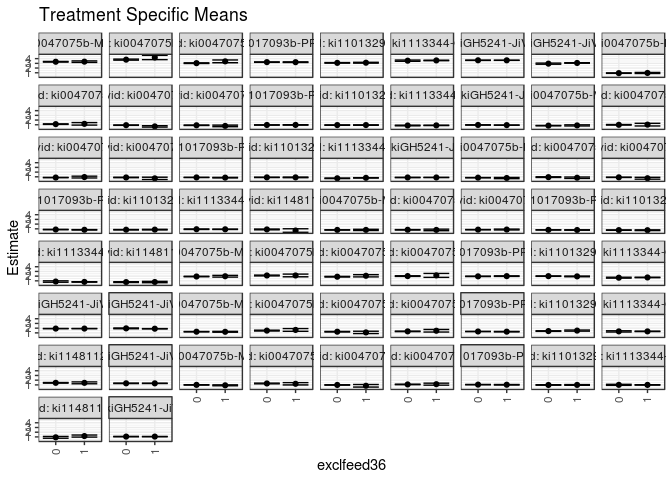

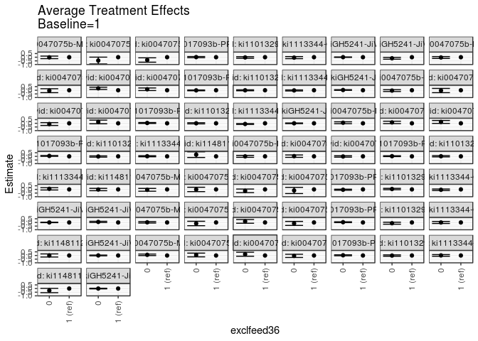

[figure not shown]

## Results Table

### Parameter: TSM

| agecat | studyid | country | intervention_level | baseline_level | estimate | ci_lower | ci_upper |
| --- | --- | --- | --- | --- | --- | --- | --- |
| 0-3 months | ki0047075b-MAL-ED | BANGLADESH | 1 | NA | 3.3614799 | 3.2004142 | 3.5225456 |
| 0-3 months | ki0047075b-MAL-ED | BANGLADESH | 0 | NA | 3.3392945 | 3.2670189 | 3.4115702 |
| 0-3 months | ki0047075b-MAL-ED | BRAZIL | 1 | NA | 4.2459722 | 3.7916926 | 4.7002519 |
| 0-3 months | ki0047075b-MAL-ED | BRAZIL | 0 | NA | 3.7865574 | 3.6750596 | 3.8980552 |
| 0-3 months | ki0047075b-MAL-ED | PERU | 1 | NA | 3.4234571 | 3.1291622 | 3.7177520 |
| 0-3 months | ki0047075b-MAL-ED | PERU | 0 | NA | 3.0417843 | 2.9741800 | 3.1093886 |
| 0-3 months | ki1017093b-PROVIDE | BANGLADESH | 1 | NA | 3.2499317 | 3.1844082 | 3.3154552 |
| 0-3 months | ki1017093b-PROVIDE | BANGLADESH | 0 | NA | 3.2606295 | 3.2164343 | 3.3048247 |
| 0-3 months | ki1101329-Keneba | GAMBIA | 1 | NA | 3.1353716 | 3.0438778 | 3.2268654 |
| 0-3 months | ki1101329-Keneba | GAMBIA | 0 | NA | 3.1020242 | 3.0408627 | 3.1631856 |
| 0-3 months | ki1113344-GMS-Nepal | NEPAL | 1 | NA | 3.6233665 | 3.5655524 | 3.6811806 |
| 0-3 months | ki1113344-GMS-Nepal | NEPAL | 0 | NA | 3.5666710 | 3.4367105 | 3.6966316 |
| 0-3 months | kiGH5241-JiVitA-3 | BANGLADESH | 1 | NA | 3.6458535 | 3.6317786 | 3.6599283 |
| 0-3 months | kiGH5241-JiVitA-3 | BANGLADESH | 0 | NA | 3.6515268 | 3.6268007 | 3.6762528 |
| 0-3 months | kiGH5241-JiVitA-4 | BANGLADESH | 1 | NA | 3.0813139 | 3.0280066 | 3.1346212 |
| 0-3 months | kiGH5241-JiVitA-4 | BANGLADESH | 0 | NA | 2.9363972 | 2.8177172 | 3.0550772 |
| 3-6 months | ki0047075b-MAL-ED | BANGLADESH | 1 | NA | 1.9770478 | 1.7914774 | 2.1626181 |
| 3-6 months | ki0047075b-MAL-ED | BANGLADESH | 0 | NA | 1.9223290 | 1.8705346 | 1.9741234 |
| 3-6 months | ki0047075b-MAL-ED | BRAZIL | 1 | NA | 2.1448082 | 1.8595938 | 2.4300226 |
| 3-6 months | ki0047075b-MAL-ED | BRAZIL | 0 | NA | 2.1401973 | 2.0577179 | 2.2226767 |
| 3-6 months | ki0047075b-MAL-ED | INDIA | 1 | NA | 2.0750209 | 1.8360347 | 2.3140071 |
| 3-6 months | ki0047075b-MAL-ED | INDIA | 0 | NA | 1.8770379 | 1.8121355 | 1.9419403 |
| 3-6 months | ki0047075b-MAL-ED | PERU | 1 | NA | 2.1589526 | 1.7407037 | 2.5772015 |
| 3-6 months | ki0047075b-MAL-ED | PERU | 0 | NA | 2.0123885 | 1.9453808 | 2.0793963 |
| 3-6 months | ki1017093b-PROVIDE | BANGLADESH | 1 | NA | 2.0015236 | 1.9372737 | 2.0657734 |
| 3-6 months | ki1017093b-PROVIDE | BANGLADESH | 0 | NA | 1.9546805 | 1.9156773 | 1.9936838 |
| 3-6 months | ki1101329-Keneba | GAMBIA | 1 | NA | 1.9490440 | 1.8713040 | 2.0267840 |
| 3-6 months | ki1101329-Keneba | GAMBIA | 0 | NA | 2.0003993 | 1.9505761 | 2.0502226 |
| 3-6 months | ki1113344-GMS-Nepal | NEPAL | 1 | NA | 1.7194325 | 1.6758816 | 1.7629835 |
| 3-6 months | ki1113344-GMS-Nepal | NEPAL | 0 | NA | 1.6661546 | 1.5691894 | 1.7631199 |

[output cut: 100 more lines]

### Parameter: E(Y)

| agecat | studyid | country | intervention_level | baseline_level | estimate | ci_lower | ci_upper |
| --- | --- | --- | --- | --- | --- | --- | --- |
| 0-3 months | ki0047075b-MAL-ED | BANGLADESH | NA | NA | 3.3402171 | 3.2743239 | 3.4061103 |
| 0-3 months | ki0047075b-MAL-ED | BRAZIL | NA | NA | 3.8085653 | 3.6991781 | 3.9179525 |
| 0-3 months | ki0047075b-MAL-ED | PERU | NA | NA | 3.0490404 | 2.9824173 | 3.1156636 |
| 0-3 months | ki1017093b-PROVIDE | BANGLADESH | NA | NA | 3.2568758 | 3.2199850 | 3.2937666 |
| 0-3 months | ki1101329-Keneba | GAMBIA | NA | NA | 3.1117460 | 3.0607980 | 3.1626940 |
| 0-3 months | ki1113344-GMS-Nepal | NEPAL | NA | NA | 3.6173812 | 3.5643204 | 3.6704421 |
| 0-3 months | kiGH5241-JiVitA-3 | BANGLADESH | NA | NA | 3.6471006 | 3.6339981 | 3.6602031 |
| 0-3 months | kiGH5241-JiVitA-4 | BANGLADESH | NA | NA | 3.0560787 | 3.0061448 | 3.1060127 |
| 3-6 months | ki0047075b-MAL-ED | BANGLADESH | NA | NA | 1.9261033 | 1.8757410 | 1.9764655 |
| 3-6 months | ki0047075b-MAL-ED | BRAZIL | NA | NA | 2.1460815 | 2.0668679 | 2.2252951 |
| 3-6 months | ki0047075b-MAL-ED | INDIA | NA | NA | 1.8848530 | 1.8216037 | 1.9481024 |
| 3-6 months | ki0047075b-MAL-ED | PERU | NA | NA | 2.0156821 | 1.9494666 | 2.0818976 |
| 3-6 months | ki1017093b-PROVIDE | BANGLADESH | NA | NA | 1.9680194 | 1.9343778 | 2.0016611 |
| 3-6 months | ki1101329-Keneba | GAMBIA | NA | NA | 1.9917249 | 1.9499823 | 2.0334676 |
| 3-6 months | ki1113344-GMS-Nepal | NEPAL | NA | NA | 1.7085606 | 1.6688133 | 1.7483079 |
| 3-6 months | kiGH5241-JiVitA-3 | BANGLADESH | NA | NA | 1.9103432 | 1.8959278 | 1.9247587 |
| 3-6 months | kiGH5241-JiVitA-4 | BANGLADESH | NA | NA | 1.8946008 | 1.8642204 | 1.9249811 |
| 6-9 months | ki0047075b-MAL-ED | BANGLADESH | NA | NA | 1.2480451 | 1.2083209 | 1.2877694 |
| 6-9 months | ki0047075b-MAL-ED | BRAZIL | NA | NA | 1.4831159 | 1.4026580 | 1.5635738 |
| 6-9 months | ki0047075b-MAL-ED | INDIA | NA | NA | 1.2403346 | 1.1889010 | 1.2917682 |
| 6-9 months | ki0047075b-MAL-ED | PERU | NA | NA | 1.3199965 | 1.2656612 | 1.3743319 |
| 6-9 months | ki1017093b-PROVIDE | BANGLADESH | NA | NA | 1.2824185 | 1.2571827 | 1.3076542 |
| 6-9 months | ki1101329-Keneba | GAMBIA | NA | NA | 1.4086727 | 1.3529368 | 1.4644086 |
| 6-9 months | ki1113344-GMS-Nepal | NEPAL | NA | NA | 1.3144775 | 1.2731267 | 1.3558284 |
| 6-9 months | ki1148112-LCNI-5 | MALAWI | NA | NA | 1.4372604 | 1.3755150 | 1.4990057 |
| 6-9 months | kiGH5241-JiVitA-4 | BANGLADESH | NA | NA | 1.3252108 | 1.3036943 | 1.3467274 |
| 9-12 months | ki0047075b-MAL-ED | BANGLADESH | NA | NA | 0.9896446 | 0.9509752 | 1.0283140 |
| 9-12 months | ki0047075b-MAL-ED | BRAZIL | NA | NA | 1.2982559 | 1.2240694 | 1.3724425 |
| 9-12 months | ki0047075b-MAL-ED | INDIA | NA | NA | 0.9798686 | 0.9411954 | 1.0185419 |
| 9-12 months | ki0047075b-MAL-ED | PERU | NA | NA | 1.0985124 | 1.0475959 | 1.1494289 |
| 9-12 months | ki1017093b-PROVIDE | BANGLADESH | NA | NA | 1.0503544 | 1.0233548 | 1.0773539 |
| 9-12 months | ki1101329-Keneba | GAMBIA | NA | NA | 0.9859004 | 0.9415938 | 1.0302070 |
| 9-12 months | ki1113344-GMS-Nepal | NEPAL | NA | NA | 0.9984152 | 0.9640726 | 1.0327578 |
| 9-12 months | ki1148112-LCNI-5 | MALAWI | NA | NA | 0.9706344 | 0.8246089 | 1.1166600 |
| 9-12 months | kiGH5241-JiVitA-4 | BANGLADESH | NA | NA | 1.0692570 | 1.0496985 | 1.0888155 |
| 12-15 months | ki0047075b-MAL-ED | BANGLADESH | NA | NA | 0.9141004 | 0.8737459 | 0.9544550 |
| 12-15 months | ki0047075b-MAL-ED | BRAZIL | NA | NA | 1.1421774 | 1.0831447 | 1.2012100 |
| 12-15 months | ki0047075b-MAL-ED | INDIA | NA | NA | 0.9075845 | 0.8681682 | 0.9470009 |
| 12-15 months | ki0047075b-MAL-ED | PERU | NA | NA | 0.8917280 | 0.8454370 | 0.9380189 |
| 12-15 months | ki1017093b-PROVIDE | BANGLADESH | NA | NA | 0.9598579 | 0.9336493 | 0.9860665 |
| 12-15 months | ki1101329-Keneba | GAMBIA | NA | NA | 0.9411780 | 0.9094953 | 0.9728606 |
| 12-15 months | ki1113344-GMS-Nepal | NEPAL | NA | NA | 0.8702474 | 0.8441404 | 0.8963544 |
| 12-15 months | kiGH5241-JiVitA-4 | BANGLADESH | NA | NA | 0.9373418 | 0.9196982 | 0.9549854 |
| 15-18 months | ki0047075b-MAL-ED | BANGLADESH | NA | NA | 0.8241226 | 0.7871907 | 0.8610544 |
| 15-18 months | ki0047075b-MAL-ED | BRAZIL | NA | NA | 1.0021114 | 0.9429996 | 1.0612232 |
| 15-18 months | ki0047075b-MAL-ED | INDIA | NA | NA | 0.8476806 | 0.8113849 | 0.8839763 |
| 15-18 months | ki0047075b-MAL-ED | PERU | NA | NA | 0.8534307 | 0.8111406 | 0.8957208 |
| 15-18 months | ki1017093b-PROVIDE | BANGLADESH | NA | NA | 0.8562969 | 0.8321689 | 0.8804249 |
| 15-18 months | ki1101329-Keneba | GAMBIA | NA | NA | 0.8768325 | 0.8429175 | 0.9107475 |
| 15-18 months | ki1113344-GMS-Nepal | NEPAL | NA | NA | 0.7596809 | 0.7265174 | 0.7928444 |
| 15-18 months | kiGH5241-JiVitA-4 | BANGLADESH | NA | NA | 0.8576466 | 0.8394619 | 0.8758313 |
| 18-21 months | ki0047075b-MAL-ED | BANGLADESH | NA | NA | 0.8133847 | 0.7790076 | 0.8477619 |
| 18-21 months | ki0047075b-MAL-ED | BRAZIL | NA | NA | 0.9160758 | 0.8452655 | 0.9868862 |
| 18-21 months | ki0047075b-MAL-ED | INDIA | NA | NA | 0.8759623 | 0.8406388 | 0.9112858 |
| 18-21 months | ki1017093b-PROVIDE | BANGLADESH | NA | NA | 0.8393900 | 0.8153565 | 0.8634234 |
| 18-21 months | ki1101329-Keneba | GAMBIA | NA | NA | 0.8164462 | 0.7785749 | 0.8543176 |
| 18-21 months | ki1113344-GMS-Nepal | NEPAL | NA | NA | 0.9045343 | 0.8683581 | 0.9407104 |
| 18-21 months | ki1148112-LCNI-5 | MALAWI | NA | NA | 0.8419773 | 0.7481346 | 0.9358201 |
| 21-24 months | ki0047075b-MAL-ED | BANGLADESH | NA | NA | 0.7694183 | 0.7339448 | 0.8048918 |
| 21-24 months | ki0047075b-MAL-ED | BRAZIL | NA | NA | 0.7961519 | 0.7521041 | 0.8401997 |
| 21-24 months | ki0047075b-MAL-ED | INDIA | NA | NA | 0.8269217 | 0.7961503 | 0.8576932 |
| 21-24 months | ki1017093b-PROVIDE | BANGLADESH | NA | NA | 0.7635979 | 0.7381659 | 0.7890298 |
| 21-24 months | ki1101329-Keneba | GAMBIA | NA | NA | 0.7224865 | 0.6857861 | 0.7591869 |
| 21-24 months | ki1113344-GMS-Nepal | NEPAL | NA | NA | 0.7920360 | 0.7445193 | 0.8395527 |
| 21-24 months | ki1148112-LCNI-5 | MALAWI | NA | NA | 0.7342569 | 0.6662316 | 0.8022822 |

### Parameter: ATE

| agecat | studyid | country | intervention_level | baseline_level | estimate | ci_lower | ci_upper |
| --- | --- | --- | --- | --- | --- | --- | --- |
| 0-3 months | ki0047075b-MAL-ED | BANGLADESH | 1 | 1 | 0.0000000 | 0.0000000 | 0.0000000 |
| 0-3 months | ki0047075b-MAL-ED | BANGLADESH | 0 | 1 | -0.0221853 | -0.1989298 | 0.1545591 |
| 0-3 months | ki0047075b-MAL-ED | BRAZIL | 1 | 1 | 0.0000000 | 0.0000000 | 0.0000000 |
| 0-3 months | ki0047075b-MAL-ED | BRAZIL | 0 | 1 | -0.4594149 | -0.9271773 | 0.0083476 |
| 0-3 months | ki0047075b-MAL-ED | PERU | 1 | 1 | 0.0000000 | 0.0000000 | 0.0000000 |
| 0-3 months | ki0047075b-MAL-ED | PERU | 0 | 1 | -0.3816728 | -0.6836328 | -0.0797128 |
| 0-3 months | ki1017093b-PROVIDE | BANGLADESH | 1 | 1 | 0.0000000 | 0.0000000 | 0.0000000 |
| 0-3 months | ki1017093b-PROVIDE | BANGLADESH | 0 | 1 | 0.0106978 | -0.0683545 | 0.0897501 |
| 0-3 months | ki1101329-Keneba | GAMBIA | 1 | 1 | 0.0000000 | 0.0000000 | 0.0000000 |
| 0-3 months | ki1101329-Keneba | GAMBIA | 0 | 1 | -0.0333474 | -0.1431274 | 0.0764325 |
| 0-3 months | ki1113344-GMS-Nepal | NEPAL | 1 | 1 | 0.0000000 | 0.0000000 | 0.0000000 |
| 0-3 months | ki1113344-GMS-Nepal | NEPAL | 0 | 1 | -0.0566955 | -0.1985444 | 0.0851535 |
| 0-3 months | kiGH5241-JiVitA-3 | BANGLADESH | 1 | 1 | 0.0000000 | 0.0000000 | 0.0000000 |
| 0-3 months | kiGH5241-JiVitA-3 | BANGLADESH | 0 | 1 | 0.0056733 | -0.0204820 | 0.0318286 |
| 0-3 months | kiGH5241-JiVitA-4 | BANGLADESH | 1 | 1 | 0.0000000 | 0.0000000 | 0.0000000 |
| 0-3 months | kiGH5241-JiVitA-4 | BANGLADESH | 0 | 1 | -0.1449167 | -0.2719828 | -0.0178506 |
| 3-6 months | ki0047075b-MAL-ED | BANGLADESH | 1 | 1 | 0.0000000 | 0.0000000 | 0.0000000 |
| 3-6 months | ki0047075b-MAL-ED | BANGLADESH | 0 | 1 | -0.0547188 | -0.2475863 | 0.1381487 |
| 3-6 months | ki0047075b-MAL-ED | BRAZIL | 1 | 1 | 0.0000000 | 0.0000000 | 0.0000000 |
| 3-6 months | ki0047075b-MAL-ED | BRAZIL | 0 | 1 | -0.0046109 | -0.3014564 | 0.2922347 |
| 3-6 months | ki0047075b-MAL-ED | INDIA | 1 | 1 | 0.0000000 | 0.0000000 | 0.0000000 |
| 3-6 months | ki0047075b-MAL-ED | INDIA | 0 | 1 | -0.1979830 | -0.4456254 | 0.0496593 |
| 3-6 months | ki0047075b-MAL-ED | PERU | 1 | 1 | 0.0000000 | 0.0000000 | 0.0000000 |
| 3-6 months | ki0047075b-MAL-ED | PERU | 0 | 1 | -0.1465641 | -0.5701466 | 0.2770185 |
| 3-6 months | ki1017093b-PROVIDE | BANGLADESH | 1 | 1 | 0.0000000 | 0.0000000 | 0.0000000 |
| 3-6 months | ki1017093b-PROVIDE | BANGLADESH | 0 | 1 | -0.0468431 | -0.1215358 | 0.0278497 |
| 3-6 months | ki1101329-Keneba | GAMBIA | 1 | 1 | 0.0000000 | 0.0000000 | 0.0000000 |
| 3-6 months | ki1101329-Keneba | GAMBIA | 0 | 1 | 0.0513553 | -0.0408089 | 0.1435195 |
| 3-6 months | ki1113344-GMS-Nepal | NEPAL | 1 | 1 | 0.0000000 | 0.0000000 | 0.0000000 |
| 3-6 months | ki1113344-GMS-Nepal | NEPAL | 0 | 1 | -0.0532779 | -0.1596895 | 0.0531337 |

[output cut: 100 more lines]

### Parameter: PAR

| agecat | studyid | country | intervention_level | baseline_level | estimate | ci_lower | ci_upper |
| --- | --- | --- | --- | --- | --- | --- | --- |
| 0-3 months | ki0047075b-MAL-ED | BANGLADESH | 1 | NA | -0.0212628 | -0.1753016 | 0.1327760 |
| 0-3 months | ki0047075b-MAL-ED | BRAZIL | 1 | NA | -0.4374070 | -0.8830117 | 0.0081977 |
| 0-3 months | ki0047075b-MAL-ED | PERU | 1 | NA | -0.3744167 | -0.6688953 | -0.0799380 |
| 0-3 months | ki1017093b-PROVIDE | BANGLADESH | 1 | NA | 0.0069441 | -0.0520638 | 0.0659520 |
| 0-3 months | ki1101329-Keneba | GAMBIA | 1 | NA | -0.0236256 | -0.1014433 | 0.0541920 |
| 0-3 months | ki1113344-GMS-Nepal | NEPAL | 1 | NA | -0.0059852 | -0.0343767 | 0.0224062 |
| 0-3 months | kiGH5241-JiVitA-3 | BANGLADESH | 1 | NA | 0.0012471 | -0.0045465 | 0.0070407 |
| 0-3 months | kiGH5241-JiVitA-4 | BANGLADESH | 1 | NA | -0.0252352 | -0.0463508 | -0.0041196 |
| 3-6 months | ki0047075b-MAL-ED | BANGLADESH | 1 | NA | -0.0509445 | -0.2199081 | 0.1180191 |
| 3-6 months | ki0047075b-MAL-ED | BRAZIL | 1 | NA | 0.0012733 | -0.2780647 | 0.2806113 |
| 3-6 months | ki0047075b-MAL-ED | INDIA | 1 | NA | -0.1901679 | -0.4280878 | 0.0477520 |
| 3-6 months | ki0047075b-MAL-ED | PERU | 1 | NA | -0.1432705 | -0.5562717 | 0.2697308 |
| 3-6 months | ki1017093b-PROVIDE | BANGLADESH | 1 | NA | -0.0335041 | -0.0903894 | 0.0233811 |
| 3-6 months | ki1101329-Keneba | GAMBIA | 1 | NA | 0.0426809 | -0.0256586 | 0.1110205 |
| 3-6 months | ki1113344-GMS-Nepal | NEPAL | 1 | NA | -0.0108719 | -0.0324841 | 0.0107402 |
| 3-6 months | kiGH5241-JiVitA-3 | BANGLADESH | 1 | NA | 0.0000299 | -0.0071739 | 0.0072338 |
| 3-6 months | kiGH5241-JiVitA-4 | BANGLADESH | 1 | NA | 0.0122947 | -0.0006462 | 0.0252357 |
| 6-9 months | ki0047075b-MAL-ED | BANGLADESH | 1 | NA | 0.0212463 | -0.0645807 | 0.1070732 |
| 6-9 months | ki0047075b-MAL-ED | BRAZIL | 1 | NA | -0.1388881 | -0.4260293 | 0.1482531 |
| 6-9 months | ki0047075b-MAL-ED | INDIA | 1 | NA | 0.1434039 | -0.1026096 | 0.3894174 |
| 6-9 months | ki0047075b-MAL-ED | PERU | 1 | NA | -0.1304608 | -0.3990978 | 0.1381761 |
| 6-9 months | ki1017093b-PROVIDE | BANGLADESH | 1 | NA | 0.0258826 | -0.0192171 | 0.0709823 |
| 6-9 months | ki1101329-Keneba | GAMBIA | 1 | NA | -0.0751698 | -0.1749481 | 0.0246085 |
| 6-9 months | ki1113344-GMS-Nepal | NEPAL | 1 | NA | 0.0005843 | -0.0266182 | 0.0277867 |
| 6-9 months | ki1148112-LCNI-5 | MALAWI | 1 | NA | 0.0057267 | -0.1741788 | 0.1856322 |
| 6-9 months | kiGH5241-JiVitA-4 | BANGLADESH | 1 | NA | 0.0016079 | -0.0089828 | 0.0121987 |
| 9-12 months | ki0047075b-MAL-ED | BANGLADESH | 1 | NA | 0.0807029 | -0.0121358 | 0.1735416 |
| 9-12 months | ki0047075b-MAL-ED | BRAZIL | 1 | NA | 0.0671214 | -0.1739360 | 0.3081788 |
| 9-12 months | ki0047075b-MAL-ED | INDIA | 1 | NA | 0.1695631 | -0.0960756 | 0.4352019 |
| 9-12 months | ki0047075b-MAL-ED | PERU | 1 | NA | -0.0506153 | -0.2653605 | 0.1641298 |
| 9-12 months | ki1017093b-PROVIDE | BANGLADESH | 1 | NA | 0.0203744 | -0.0275378 | 0.0682867 |
| 9-12 months | ki1101329-Keneba | GAMBIA | 1 | NA | -0.0064454 | -0.0717906 | 0.0588999 |
| 9-12 months | ki1113344-GMS-Nepal | NEPAL | 1 | NA | 0.0026752 | -0.0188299 | 0.0241804 |
| 9-12 months | ki1148112-LCNI-5 | MALAWI | 1 | NA | -0.2105238 | -0.4254201 | 0.0043726 |
| 9-12 months | kiGH5241-JiVitA-4 | BANGLADESH | 1 | NA | 0.0009032 | -0.0091881 | 0.0109945 |
| 12-15 months | ki0047075b-MAL-ED | BANGLADESH | 1 | NA | -0.0444435 | -0.1566682 | 0.0677811 |
| 12-15 months | ki0047075b-MAL-ED | BRAZIL | 1 | NA | -0.0556893 | -0.3118764 | 0.2004977 |
| 12-15 months | ki0047075b-MAL-ED | INDIA | 1 | NA | 0.2523161 | 0.1073622 | 0.3972700 |
| 12-15 months | ki0047075b-MAL-ED | PERU | 1 | NA | 0.1336334 | -0.0373524 | 0.3046192 |
| 12-15 months | ki1017093b-PROVIDE | BANGLADESH | 1 | NA | -0.0122696 | -0.0545956 | 0.0300563 |
| 12-15 months | ki1101329-Keneba | GAMBIA | 1 | NA | -0.0038063 | -0.0474906 | 0.0398780 |
| 12-15 months | ki1113344-GMS-Nepal | NEPAL | 1 | NA | -0.0005545 | -0.0147058 | 0.0135968 |
| 12-15 months | kiGH5241-JiVitA-4 | BANGLADESH | 1 | NA | 0.0088620 | -0.0011824 | 0.0189064 |
| 15-18 months | ki0047075b-MAL-ED | BANGLADESH | 1 | NA | -0.0416585 | -0.1535172 | 0.0702003 |
| 15-18 months | ki0047075b-MAL-ED | BRAZIL | 1 | NA | -0.0317544 | -0.3057866 | 0.2422778 |
| 15-18 months | ki0047075b-MAL-ED | INDIA | 1 | NA | -0.0977056 | -0.2842204 | 0.0888092 |
| 15-18 months | ki0047075b-MAL-ED | PERU | 1 | NA | 0.1838263 | -0.0598294 | 0.4274820 |
| 15-18 months | ki1017093b-PROVIDE | BANGLADESH | 1 | NA | 0.0332873 | -0.0100728 | 0.0766475 |
| 15-18 months | ki1101329-Keneba | GAMBIA | 1 | NA | 0.0004290 | -0.0541219 | 0.0549799 |
| 15-18 months | ki1113344-GMS-Nepal | NEPAL | 1 | NA | -0.0168996 | -0.0306509 | -0.0031483 |
| 15-18 months | kiGH5241-JiVitA-4 | BANGLADESH | 1 | NA | 0.0016169 | -0.0078120 | 0.0110457 |
| 18-21 months | ki0047075b-MAL-ED | BANGLADESH | 1 | NA | 0.0734127 | -0.0409095 | 0.1877349 |
| 18-21 months | ki0047075b-MAL-ED | BRAZIL | 1 | NA | 0.1153349 | -0.0387241 | 0.2693939 |
| 18-21 months | ki0047075b-MAL-ED | INDIA | 1 | NA | 0.1799418 | -0.0125521 | 0.3724358 |
| 18-21 months | ki1017093b-PROVIDE | BANGLADESH | 1 | NA | 0.0469082 | 0.0044617 | 0.0893547 |
| 18-21 months | ki1101329-Keneba | GAMBIA | 1 | NA | -0.0128716 | -0.0704210 | 0.0446777 |
| 18-21 months | ki1113344-GMS-Nepal | NEPAL | 1 | NA | 0.0047873 | -0.0086520 | 0.0182266 |
| 18-21 months | ki1148112-LCNI-5 | MALAWI | 1 | NA | 0.2082734 | -0.1147547 | 0.5313016 |
| 21-24 months | ki0047075b-MAL-ED | BANGLADESH | 1 | NA | 0.0031365 | -0.1152596 | 0.1215326 |
| 21-24 months | ki0047075b-MAL-ED | BRAZIL | 1 | NA | 0.0308508 | -0.1248326 | 0.1865343 |
| 21-24 months | ki0047075b-MAL-ED | INDIA | 1 | NA | -0.0165759 | -0.1090840 | 0.0759322 |
| 21-24 months | ki1017093b-PROVIDE | BANGLADESH | 1 | NA | 0.0179685 | -0.0257171 | 0.0616541 |
| 21-24 months | ki1101329-Keneba | GAMBIA | 1 | NA | 0.0123328 | -0.0498535 | 0.0745191 |
| 21-24 months | ki1113344-GMS-Nepal | NEPAL | 1 | NA | 0.0191372 | -0.0091406 | 0.0474150 |
| 21-24 months | ki1148112-LCNI-5 | MALAWI | 1 | NA | -0.0153613 | -0.1494232 | 0.1187005 |